# 1. 타이타닉 생존자 분류 모델 테스트

### (1) 목적 : 어느 모델이 타이타닉 생존자 분류에 더 적합한지 테스트하기 위함

### (2) 테스트 모델 : 로지스틱 회귀 vs 결정 트리

### (3) 평가 지표 : 혼동 행렬, F1-score, ROC/AUC

### (4) 리뷰:

#### 1. 데이터 전처리를 하기 전에 모델에 포함시킬 특성을 잘 선택해야

- 가령 결측치가 가장 많은 deck의 경우, 상관관계만으로 봤을 때는 모델링에 있어 꽤 중요한 특성처럼 보이지만, 그 자체가 class 등과 높은 상관관계를 가지고 있어 사실상 제외해도 큰 문제는 없었다.
- age 역시 who, adult_male 등으로 충분히 대체할 수 있으므로 굳이 결측치를 고려할 필요가 없다는 판단을 내릴 수 있었다.
- 위처럼 유사성을 가진 특성들, class와 pclass처럼 완전히 동일한 특성들을 우선적으로 확인하고 전처리를 시작하는 편이 좋다는 것을 느낀다. #### 2. 상식과 지식을 토대로, 표면적 점수에 너무 얽매여서는 안 돼
- 아무리 다양한 조건의 영향을 받았다 해도, 사람의 생존여부를 조건에 따라 90% 이상 맞춘다는 것은 오히려 비현실적이다. 80% 이상 예측할 수 있다는 것만으로도 충분히 안타까운 사고임을 고려한다면 점수를 높이는 데 너무 얽매일 필요가 없다는 판단을 내릴 수 있었다.

### [1] 데이터 확인

```python
import pandas as pd
import seaborn as sns
import numpy as np

tit = sns.load_dataset('titanic')
tit.head()
```

|  | survived | pclass | sex | age | sibsp | parch | fare | embarked | class | who | adult_male | deck | embark_town | alive | alone |
| --- | --- | --- | --- | --- | --- | --- | --- | --- | --- | --- | --- | --- | --- | --- | --- |
| 0 | 0 | 3 | male | 22.0 | 1 | 0 | 7.2500 | S | Third | man | True | NaN | Southampton | no | False |
| 1 | 1 | 1 | female | 38.0 | 1 | 0 | 71.2833 | C | First | woman | False | C | Cherbourg | yes | False |
| 2 | 1 | 3 | female | 26.0 | 0 | 0 | 7.9250 | S | Third | woman | False | NaN | Southampton | yes | True |
| 3 | 1 | 1 | female | 35.0 | 1 | 0 | 53.1000 | S | First | woman | False | C | Southampton | yes | False |
| 4 | 0 | 3 | male | 35.0 | 0 | 0 | 8.0500 | S | Third | man | True | NaN | Southampton | no | True |

```python
tit.info()
```

```
<class 'pandas.core.frame.DataFrame'>
RangeIndex: 891 entries, 0 to 890
Data columns (total 15 columns):
 #   Column       Non-Null Count  Dtype
---  ------       --------------  -----
 0   survived     891 non-null    int64
 1   pclass       891 non-null    int64
 2   sex          891 non-null    object
 3   age          714 non-null    float64
 4   sibsp        891 non-null    int64
 5   parch        891 non-null    int64
 6   fare         891 non-null    float64
 7   embarked     889 non-null    object
 8   class        891 non-null    category
 9   who          891 non-null    object
 10  adult_male   891 non-null    bool
 11  deck         203 non-null    category
 12  embark_town  889 non-null    object
 13  alive        891 non-null    object
 14  alone        891 non-null    bool
dtypes: bool(2), category(2), float64(2), int64(4), object(5)
memory usage: 80.7+ KB
```

- age, deck, embarked, embark_town에 결측값이 존재한다.
- 필요한 특성이라면 결측치를 대체해서라도 모델에 포함시키도록 하자.

### [2] 모든 특성을 숫자로 인코딩 후 상관관계 확인

```python
from sklearn.preprocessing import LabelEncoder

le = LabelEncoder()

tit_enc = tit.apply(lambda x: le.fit_transform(x) if x.dtype in ['O', 'category'] else x)
tit_enc.head()
```

|  | survived | pclass | sex | age | sibsp | parch | fare | embarked | class | who | adult_male | deck | embark_town | alive | alone |
| --- | --- | --- | --- | --- | --- | --- | --- | --- | --- | --- | --- | --- | --- | --- | --- |
| 0 | 0 | 3 | 1 | 22.0 | 1 | 0 | 7.2500 | 2 | 2 | 1 | True | 7 | 2 | 0 | False |
| 1 | 1 | 1 | 0 | 38.0 | 1 | 0 | 71.2833 | 0 | 0 | 2 | False | 2 | 0 | 1 | False |
| 2 | 1 | 3 | 0 | 26.0 | 0 | 0 | 7.9250 | 2 | 2 | 2 | False | 7 | 2 | 1 | True |
| 3 | 1 | 1 | 0 | 35.0 | 1 | 0 | 53.1000 | 2 | 0 | 2 | False | 2 | 2 | 1 | False |
| 4 | 0 | 3 | 1 | 35.0 | 0 | 0 | 8.0500 | 2 | 2 | 1 | True | 7 | 2 | 0 | True |

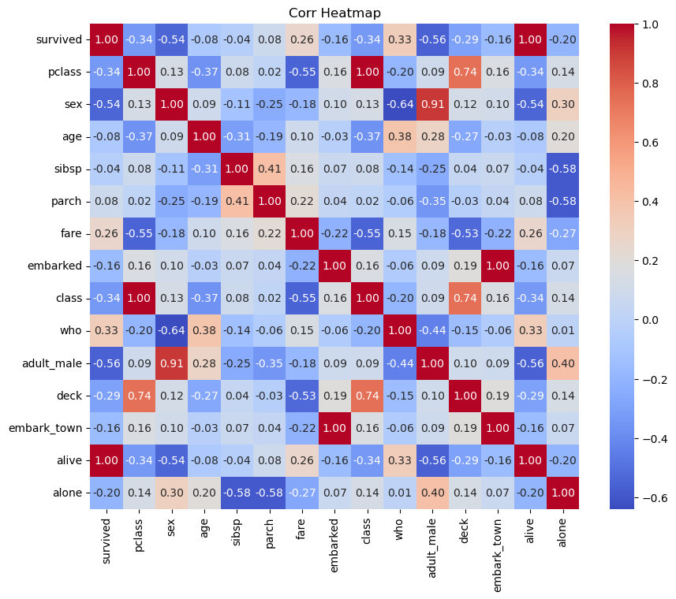

```
adult_male    -0.557080
sex           -0.543351
class         -0.338481
pclass        -0.338481
deck          -0.294804
alone         -0.203367
embarked      -0.163517
embark_town   -0.163517
age           -0.077221
sibsp         -0.035322
parch          0.081629
fare           0.257307
who            0.325753
survived       1.000000
alive          1.000000
Name: survived, dtype: float64
```

```python
import matplotlib.pyplot as plt

plt.figure(figsize=(10, 8))
sns.heatmap(tit_enc.corr(), annot=True, cmap='coolwarm', fmt=".2f")
plt.title("Corr Heatmap")
plt.show()

high_corr_survived = tit_enc.corr()['survived'].sort_values(ascending=True)
print(high_corr_survived)
```

- 성인 남성인지 여부가 가장 핵심적인 특성이다.
- class와 pclass는 타입만 다를 뿐 완전히 같은 특성이다. 숫자형인 pclass만 포함하기로 한다.
- age, embark_town은 생존과 큰 상관이 없으니 제외해도 되겠다.
- deck도 survived에 영향을 주기는 했으나, 결측치가 많고, 그 자체가 class와 0.74의 높은 상관관계를 가지고 있으니 제외해도 되겠다.
- 결론적으로 adult_male, sex, pclass, who, fare 특성값으로 모델링할 수 있겠다.(사실 이 안에서도 겹치는 게 있지만, 테스트 과정에서 개선해도 됨)

### [3] 데이터 전처리

- 숫자 타입의 sex/who 컬럼을 데이터에 추가하고, 결측치가 존재하는 컬럼을 제외한다.
- 결측치 데이터를 싹쓸어버리는 dropna 말고 drop([컬럼리스트],axis=1)을 활용한다.

```python
tit['sex_no'] = tit_enc['sex']
tit['who_no'] = tit_enc['who']
tit = tit.drop(['age','embark_town','embarked','deck'],axis=1)
tit.info()
```

```
<class 'pandas.core.frame.DataFrame'>
RangeIndex: 891 entries, 0 to 890
Data columns (total 13 columns):
 #   Column      Non-Null Count  Dtype
---  ------      --------------  -----
 0   survived    891 non-null    int64
 1   pclass      891 non-null    int64
 2   sex         891 non-null    object
 3   sibsp       891 non-null    int64
 4   parch       891 non-null    int64
 5   fare        891 non-null    float64
 6   class       891 non-null    category
 7   who         891 non-null    object
 8   adult_male  891 non-null    bool
 9   alive       891 non-null    object
 10  alone       891 non-null    bool
 11  sex_no      891 non-null    int64
 12  who_no      891 non-null    int64
dtypes: bool(2), category(1), float64(1), int64(6), object(3)
memory usage: 72.5+ KB
```

- 이제 결측치는 존재하지 않는다. 모델링을 시작하자.

### [4-1] 로지스틱 회귀 모델링

```python
from sklearn.model_selection import train_test_split
from sklearn.preprocessing import StandardScaler
from sklearn.linear_model import LogisticRegression

X = tit[['adult_male','pclass','sex_no','who_no','fare']]
y = tit['survived']

X_train, X_test, y_train, y_test = train_test_split(X, y, test_size=0.3, random_state=42)

ss = StandardScaler()
X_train_scaled = ss.fit_transform(X_train)
X_test_scaled = ss.fit_transform(X_test)

lr = LogisticRegression(C=0.5)
lr.fit(X_train_scaled,y_train)

print(lr.score(X_train_scaled,y_train))
print(lr.score(X_test_scaled,y_test))
```

```
0.8025682182985554
0.8022388059701493
```

- 규제를 0.5로 맞추었을 때 가장 적절한 점수가 나온다.
- 컴퓨터놈이 로지스틱 회귀로 감히 사람 생사를 판단하는데 80점이나 나온다는 건 잔인한 사실이다. 더 높은 점수를 바라지 말자.

```
==============================
학습 혼동 행렬
[[334  58]
 [ 65 166]]
테스트 혼동 행렬
[[134  23]
 [ 30  81]]
==============================
학습 분류 보고서:
              precision    recall  f1-score   support

           0       0.84      0.85      0.84       392
           1       0.74      0.72      0.73       231

    accuracy                           0.80       623
   macro avg       0.79      0.79      0.79       623
weighted avg       0.80      0.80      0.80       623


테스트 분류 보고서:
              precision    recall  f1-score   support

           0       0.82      0.85      0.83       157
           1       0.78      0.73      0.75       111

    accuracy                           0.80       268
   macro avg       0.80      0.79      0.79       268
weighted avg       0.80      0.80      0.80       268

==============================
```

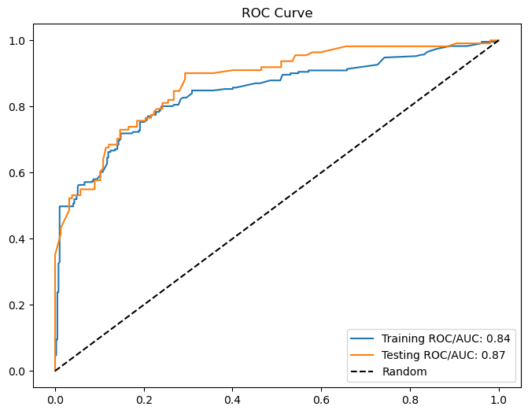

```python
from sklearn.metrics import confusion_matrix, classification_report, roc_auc_score, roc_curve
import matplotlib.pyplot as plt

y_train_pred = lr.predict(X_train_scaled)
y_test_pred = lr.predict(X_test_scaled)

conf_matrix_train = confusion_matrix(y_train, y_train_pred)
conf_matrix_test = confusion_matrix(y_test, y_test_pred)
print("==============================")
print("학습 혼동 행렬")
print(conf_matrix_train)
print("테스트 혼동 행렬")
print(conf_matrix_test)
print("==============================")
print("학습 분류 보고서:")
print(classification_report(y_train, y_train_pred))
print("\n테스트 분류 보고서:")
print(classification_report(y_test, y_test_pred))
print("==============================")
y_train_proba = lr.predict_proba(X_train_scaled)[:, 1]
y_test_proba = lr.predict_proba(X_test_scaled)[:, 1]

roc_auc_train = roc_auc_score(y_train, y_train_proba)
roc_auc_test = roc_auc_score(y_test, y_test_proba)

fpr_train, tpr_train, _ = roc_curve(y_train, y_train_proba)
fpr_test, tpr_test, _ = roc_curve(y_test, y_test_proba)

plt.figure(figsize=(8, 6))
plt.plot(fpr_train, tpr_train, label=f'Training ROC/AUC: {roc_auc_train:.2f}')
plt.plot(fpr_test, tpr_test, label=f'Testing ROC/AUC: {roc_auc_test:.2f}')
plt.plot([0, 1], [0, 1], 'k--', label='Random')
plt.title('ROC Curve')
plt.legend()
plt.show()
```

### [4-2] 결정 트리 모델링

```python
from sklearn.model_selection import train_test_split
from sklearn.preprocessing import StandardScaler
from sklearn.tree import DecisionTreeClassifier

X = tit[['adult_male','pclass','sex_no','who_no','fare']]
y = tit['survived']

X_train, X_test, y_train, y_test = train_test_split(X, y, test_size=0.3, random_state=42)

ss = StandardScaler()
X_train_scaled = ss.fit_transform(X_train)
X_test_scaled = ss.fit_transform(X_test)

dt = DecisionTreeClassifier(max_depth=5)
dt.fit(X_train_scaled,y_train)

print(dt.score(X_train_scaled,y_train))
print(dt.score(X_test_scaled,y_test))
```

```
0.8571428571428571
0.8208955223880597
```

- max_depth=5를 해주니 적절한 점수가 나온다.
- 예상은 했지만 결정 트리는 더 잔인한 놈이다.

```
==============================
학습 혼동 행렬
[[358  34]
 [ 55 176]]
테스트 혼동 행렬
[[140  17]
 [ 31  80]]
==============================
학습 분류 보고서:
              precision    recall  f1-score   support

           0       0.87      0.91      0.89       392
           1       0.84      0.76      0.80       231

    accuracy                           0.86       623
   macro avg       0.85      0.84      0.84       623
weighted avg       0.86      0.86      0.86       623


테스트 분류 보고서:
              precision    recall  f1-score   support

           0       0.82      0.89      0.85       157
           1       0.82      0.72      0.77       111

    accuracy                           0.82       268
   macro avg       0.82      0.81      0.81       268
weighted avg       0.82      0.82      0.82       268

==============================
```

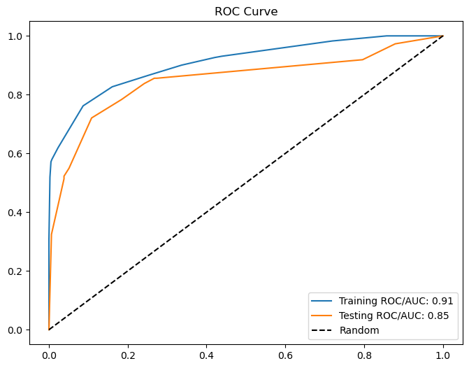

```python
from sklearn.metrics import confusion_matrix, classification_report, roc_auc_score, roc_curve
import matplotlib.pyplot as plt

y_train_pred = dt.predict(X_train_scaled)
y_test_pred = dt.predict(X_test_scaled)

conf_matrix_train = confusion_matrix(y_train, y_train_pred)
conf_matrix_test = confusion_matrix(y_test, y_test_pred)
print("==============================")
print("학습 혼동 행렬")
print(conf_matrix_train)
print("테스트 혼동 행렬")
print(conf_matrix_test)
print("==============================")
print("학습 분류 보고서:")
print(classification_report(y_train, y_train_pred))
print("\n테스트 분류 보고서:")
print(classification_report(y_test, y_test_pred))
print("==============================")
y_train_proba = dt.predict_proba(X_train_scaled)[:, 1]
y_test_proba = dt.predict_proba(X_test_scaled)[:, 1]

roc_auc_train = roc_auc_score(y_train, y_train_proba)
roc_auc_test = roc_auc_score(y_test, y_test_proba)

fpr_train, tpr_train, _ = roc_curve(y_train, y_train_proba)
fpr_test, tpr_test, _ = roc_curve(y_test, y_test_proba)

plt.figure(figsize=(8, 6))
plt.plot(fpr_train, tpr_train, label=f'Training ROC/AUC: {roc_auc_train:.2f}')
plt.plot(fpr_test, tpr_test, label=f'Testing ROC/AUC: {roc_auc_test:.2f}')
plt.plot([0, 1], [0, 1], 'k--', label='Random')
plt.title('ROC Curve')
plt.legend()
plt.show()
```

- 학습 정확도: 약 86%
- 테스트 정확도: 약 82%
- 학습 정밀도: 약 84%
- 테스트 정밀도: 약 82%
- 학습 재현율: 약 76%
- 테스트 재현율: 약 72%
- 학습 F1 스코어: 약 80%
- 테스트 F1 스코어: 약 77%
- 학습 ROC/AUC: 약 0.91
- 테스트 ROC/AUC: 약 0.85

#### 종합적으로 결정 트리 모델이 더 높은 정확도를 보인다. 대신 과적합의 소지도 있으니 더 세밀한 튜닝이 필요할 수 있다.